# Demo

Sebastian Wójcik

24-04-2023

Mail do kontaktu: s.wojcik@stat.gov.pl Dużo szczegółów jest na stronie [rmarkdown](https://bookdown.org/yihui/rmarkdown/) bądź [rmarkdown2](https://bookdown.org/yihui/rmarkdown-cookbook/). Tutaj podaje podstawy pliku html.

# Nagłówek 1

## Nagłówek 2

### Nagłówek 3

#### Nagłówek 4

Numerowanie / punktowanie (musi być linia przerwy przed punktowaniem)

- raz
- dwa
- trzy

Listy zagnieżdżone tworzone przez *, +, - (niższe poziomy muszą być poprzedzone wcięciem Tab)

- owoce
  - jabłko
    - Jonagold
    - Golden Delicious
  - śliwka
  - gruszka
- warzywa
  - marchewka
  - seler
- owoce
  - jabłko
    - Jonagold
    - Golden Delicious
      - śliwka
  - gruszka
- warzywa
  - marchewka
  - seler

Kluczowe znaczenie ma wcięcie a nie typ znacznika

- owoce
- jabłko
- Jonagold
- Golden Delicious
- śliwka
- gruszka
- warzywa
- marchewka
- seler

Więcj opcji w pakietach `fancy_list` czy `startnum`.

# Formatowanie

Linki [google](https://google.com)

*kursywa*

**pogrubienie**

*kursywa i pogrubienie*

*kursywa*

**pogrubienie**

*tekst*

kolor czerwony

Linie poziome

## Kod R

Fragmenty kodów są inicjowane i zamykane poprzez “```". Fragment kodu składa się z określenia języka i opcji w pierwszej linijce. Po określeniu języka można nadać nazwę fragmentu, aby móc się do niego odwołać. Poniżej nazwano go`cars`.

Ładuje zbiory danych

```r
summary(cars)
```

```
##      speed           dist
##  Min.   : 4.0   Min.   :  2.00
##  1st Qu.:12.0   1st Qu.: 26.00
##  Median :15.0   Median : 36.00
##  Mean   :15.4   Mean   : 42.98
##  3rd Qu.:19.0   3rd Qu.: 56.00
##  Max.   :25.0   Max.   :120.00
```

```r
srednie=colMeans(cars)
srednie
```

```
## speed  dist
## 15.40 42.98
```

Najważniejsze opcje kodu

- include = FALSE - czy pokazać kod i wyniki? Kod zawsze jest wykonywany
- eval = FALSE - czy wykonywać kod?
- echo = FALSE - czy pokazać kod?
- message = FALSE - czy pokazać wiadomości?
- warning = FALSE - czy pokazać ostrzeżenia?

## Rysunek

Opcje rysunku zaczynają się od *fig*.

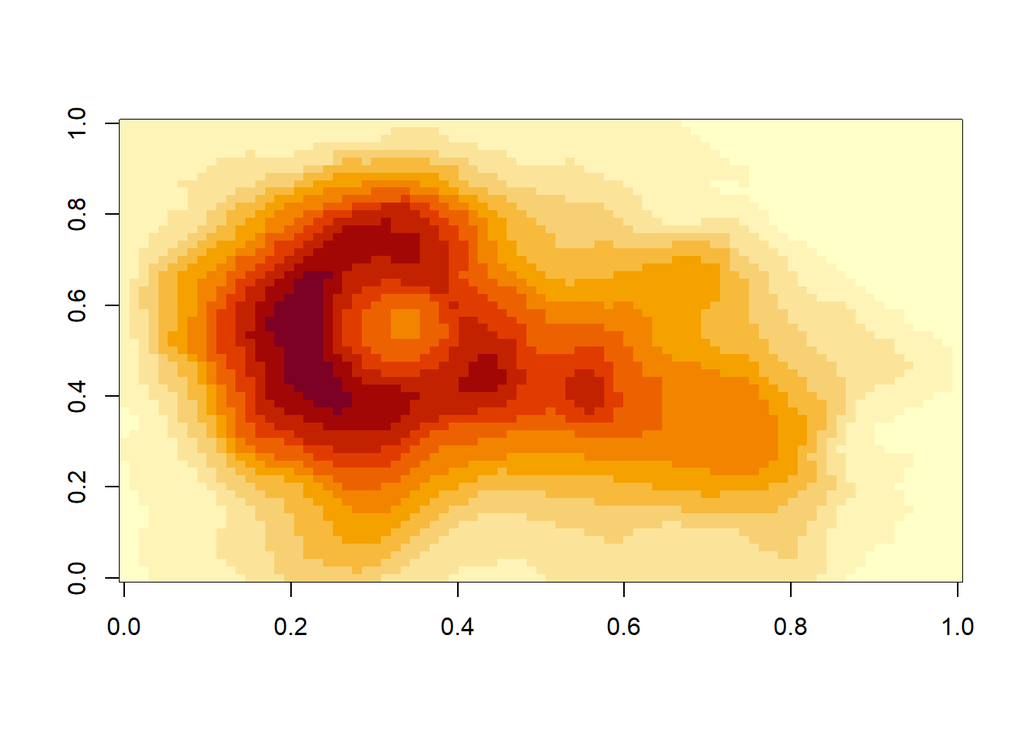

Temperatura wulkanu

```r
image(volcano)
```

## Fragmenty innych kodów

Dostępne są języki: python, Rcpp, SQL, Stan, Bash i D3. Zazwyczaj trzeba doinstalować pakiety np. do pythona jest `miniconda`. We fragmencie kodu należy ustawić język.

```python
x = 'witamy w świecie python'
print(x.split(' '))
```

```
## ['witamy', 'w', 'świecie', 'python']
```

```r
x = 'witamy w świecie python'
gsub(pattern = 'python',x = x,replacement = 'R')
```

```
## [1] "witamy w świecie R"
```

Możliwe jest przechodzenie między dwoma środowiskami. Za pomocą pakietu `reticulate` można tworzyć wirtualną maszynę. Poniższy kod inicjuje pythona z mojego dysku (działa lokalnie).

```r
library(reticulate)
path <- "C:/Users/wojcikse/AppData/Local/Programs/Python/Python39"
# use_python(path)
```

Utwórzmy wektor w pythonie.

```python
my_python_array = list([2,4,6,8])
```

A teraz w R odwołuje się do środowiska w pythonie poprzez `py`. Konwertuje na wektor i wykonuje pewne operacje.

```r
my_r_array <- py$my_python_array
my_r_vector <- as.vector(py$my_python_array)
class(my_r_vector)
```

```
## [1] "integer"
```

```r
my_r_vector <- my_r_vector * 2
my_r_vector
```

```
## [1]  4  8 12 16
```

Wracam do pythona i odwołuje się do środowiska w R poprzez `r`.

```python
my_python_array2 = r.my_r_vector
print(my_python_array2)
```

```
## [4.0, 8.0, 12.0, 16.0]
```

W środowisku R można wywołać bezpośrednio kod pythona opakowując go komendą `py_run_string` i zamieszczając kod pythona w cudzysłowiu.

```r
reticulate::py_run_string("print(my_python_array2)")
```

## Tabele

Brzydsza tabela

```
##                      mpg cyl  disp  hp drat
## Mazda RX4           21.0   6 160.0 110 3.90
## Mazda RX4 Wag       21.0   6 160.0 110 3.90
## Datsun 710          22.8   4 108.0  93 3.85
## Hornet 4 Drive      21.4   6 258.0 110 3.08
## Hornet Sportabout   18.7   8 360.0 175 3.15
## Valiant             18.1   6 225.0 105 2.76
## Duster 360          14.3   8 360.0 245 3.21
## Merc 240D           24.4   4 146.7  62 3.69
## Merc 230            22.8   4 140.8  95 3.92
## Merc 280            19.2   6 167.6 123 3.92
## Merc 280C           17.8   6 167.6 123 3.92
## Merc 450SE          16.4   8 275.8 180 3.07
## Merc 450SL          17.3   8 275.8 180 3.07
## Merc 450SLC         15.2   8 275.8 180 3.07
## Cadillac Fleetwood  10.4   8 472.0 205 2.93
## Lincoln Continental 10.4   8 460.0 215 3.00
## Chrysler Imperial   14.7   8 440.0 230 3.23
## Fiat 128            32.4   4  78.7  66 4.08
## Honda Civic         30.4   4  75.7  52 4.93
## Toyota Corolla      33.9   4  71.1  65 4.22
## Toyota Corona       21.5   4 120.1  97 3.70
## Dodge Challenger    15.5   8 318.0 150 2.76
## AMC Javelin         15.2   8 304.0 150 3.15
## Camaro Z28          13.3   8 350.0 245 3.73
## Pontiac Firebird    19.2   8 400.0 175 3.08
## Fiat X1-9           27.3   4  79.0  66 4.08
## Porsche 914-2       26.0   4 120.3  91 4.43
## Lotus Europa        30.4   4  95.1 113 3.77
## Ford Pantera L      15.8   8 351.0 264 4.22
## Ferrari Dino        19.7   6 145.0 175 3.62
## Maserati Bora       15.0   8 301.0 335 3.54
## Volvo 142E          21.4   4 121.0 109 4.11
```

Tabela z użyciem pakietu `knitr`.

Tabela z knitr

|  | mpg | cyl | disp | hp | drat |
| --- | --- | --- | --- | --- | --- |
| Mazda RX4 | 21.0 | 6 | 160.0 | 110 | 3.90 |
| Mazda RX4 Wag | 21.0 | 6 | 160.0 | 110 | 3.90 |
| Datsun 710 | 22.8 | 4 | 108.0 | 93 | 3.85 |
| Hornet 4 Drive | 21.4 | 6 | 258.0 | 110 | 3.08 |
| Hornet Sportabout | 18.7 | 8 | 360.0 | 175 | 3.15 |
| Valiant | 18.1 | 6 | 225.0 | 105 | 2.76 |
| Duster 360 | 14.3 | 8 | 360.0 | 245 | 3.21 |
| Merc 240D | 24.4 | 4 | 146.7 | 62 | 3.69 |
| Merc 230 | 22.8 | 4 | 140.8 | 95 | 3.92 |
| Merc 280 | 19.2 | 6 | 167.6 | 123 | 3.92 |
| Merc 280C | 17.8 | 6 | 167.6 | 123 | 3.92 |
| Merc 450SE | 16.4 | 8 | 275.8 | 180 | 3.07 |
| Merc 450SL | 17.3 | 8 | 275.8 | 180 | 3.07 |
| Merc 450SLC | 15.2 | 8 | 275.8 | 180 | 3.07 |
| Cadillac Fleetwood | 10.4 | 8 | 472.0 | 205 | 2.93 |
| Lincoln Continental | 10.4 | 8 | 460.0 | 215 | 3.00 |
| Chrysler Imperial | 14.7 | 8 | 440.0 | 230 | 3.23 |
| Fiat 128 | 32.4 | 4 | 78.7 | 66 | 4.08 |
| Honda Civic | 30.4 | 4 | 75.7 | 52 | 4.93 |
| Toyota Corolla | 33.9 | 4 | 71.1 | 65 | 4.22 |
| Toyota Corona | 21.5 | 4 | 120.1 | 97 | 3.70 |
| Dodge Challenger | 15.5 | 8 | 318.0 | 150 | 2.76 |
| AMC Javelin | 15.2 | 8 | 304.0 | 150 | 3.15 |
| Camaro Z28 | 13.3 | 8 | 350.0 | 245 | 3.73 |
| Pontiac Firebird | 19.2 | 8 | 400.0 | 175 | 3.08 |
| Fiat X1-9 | 27.3 | 4 | 79.0 | 66 | 4.08 |
| Porsche 914-2 | 26.0 | 4 | 120.3 | 91 | 4.43 |
| Lotus Europa | 30.4 | 4 | 95.1 | 113 | 3.77 |
| Ford Pantera L | 15.8 | 8 | 351.0 | 264 | 4.22 |
| Ferrari Dino | 19.7 | 6 | 145.0 | 175 | 3.62 |
| Maserati Bora | 15.0 | 8 | 301.0 | 335 | 3.54 |
| Volvo 142E | 21.4 | 4 | 121.0 | 109 | 4.11 |

|  | mpg | cyl | disp | hp | drat | wt | qsec | vs | am | gear | carb |
| --- | --- | --- | --- | --- | --- | --- | --- | --- | --- | --- | --- |
| Mazda RX4 | 21.0 | 6 | 160.0 | 110 | 3.90 | 2.62 | 16.46 | 0 | 1 | 4 | 4 |
| Mazda RX4 Wag | 21.0 | 6 | 160.0 | 110 | 3.90 | 2.88 | 17.02 | 0 | 1 | 4 | 4 |
| Datsun 710 | 22.8 | 4 | 108.0 | 93 | 3.85 | 2.32 | 18.61 | 1 | 1 | 4 | 1 |
| Hornet 4 Drive | 21.4 | 6 | 258.0 | 110 | 3.08 | 3.21 | 19.44 | 1 | 0 | 3 | 1 |
| Hornet Sportabout | 18.7 | 8 | 360.0 | 175 | 3.15 | 3.44 | 17.02 | 0 | 0 | 3 | 2 |
| Valiant | 18.1 | 6 | 225.0 | 105 | 2.76 | 3.46 | 20.22 | 1 | 0 | 3 | 1 |
| Duster 360 | 14.3 | 8 | 360.0 | 245 | 3.21 | 3.57 | 15.84 | 0 | 0 | 3 | 4 |
| Merc 240D | 24.4 | 4 | 146.7 | 62 | 3.69 | 3.19 | 20.00 | 1 | 0 | 4 | 2 |
| Merc 230 | 22.8 | 4 | 140.8 | 95 | 3.92 | 3.15 | 22.90 | 1 | 0 | 4 | 2 |
| Merc 280 | 19.2 | 6 | 167.6 | 123 | 3.92 | 3.44 | 18.30 | 1 | 0 | 4 | 4 |
| Merc 280C | 17.8 | 6 | 167.6 | 123 | 3.92 | 3.44 | 18.90 | 1 | 0 | 4 | 4 |
| Merc 450SE | 16.4 | 8 | 275.8 | 180 | 3.07 | 4.07 | 17.40 | 0 | 0 | 3 | 3 |
| Merc 450SL | 17.3 | 8 | 275.8 | 180 | 3.07 | 3.73 | 17.60 | 0 | 0 | 3 | 3 |
| Merc 450SLC | 15.2 | 8 | 275.8 | 180 | 3.07 | 3.78 | 18.00 | 0 | 0 | 3 | 3 |
| Cadillac Fleetwood | 10.4 | 8 | 472.0 | 205 | 2.93 | 5.25 | 17.98 | 0 | 0 | 3 | 4 |
| Lincoln Continental | 10.4 | 8 | 460.0 | 215 | 3.00 | 5.42 | 17.82 | 0 | 0 | 3 | 4 |
| Chrysler Imperial | 14.7 | 8 | 440.0 | 230 | 3.23 | 5.34 | 17.42 | 0 | 0 | 3 | 4 |
| Fiat 128 | 32.4 | 4 | 78.7 | 66 | 4.08 | 2.20 | 19.47 | 1 | 1 | 4 | 1 |
| Honda Civic | 30.4 | 4 | 75.7 | 52 | 4.93 | 1.61 | 18.52 | 1 | 1 | 4 | 2 |
| Toyota Corolla | 33.9 | 4 | 71.1 | 65 | 4.22 | 1.83 | 19.90 | 1 | 1 | 4 | 1 |
| Toyota Corona | 21.5 | 4 | 120.1 | 97 | 3.70 | 2.46 | 20.01 | 1 | 0 | 3 | 1 |
| Dodge Challenger | 15.5 | 8 | 318.0 | 150 | 2.76 | 3.52 | 16.87 | 0 | 0 | 3 | 2 |
| AMC Javelin | 15.2 | 8 | 304.0 | 150 | 3.15 | 3.44 | 17.30 | 0 | 0 | 3 | 2 |
| Camaro Z28 | 13.3 | 8 | 350.0 | 245 | 3.73 | 3.84 | 15.41 | 0 | 0 | 3 | 4 |
| Pontiac Firebird | 19.2 | 8 | 400.0 | 175 | 3.08 | 3.85 | 17.05 | 0 | 0 | 3 | 2 |
| Fiat X1-9 | 27.3 | 4 | 79.0 | 66 | 4.08 | 1.94 | 18.90 | 1 | 1 | 4 | 1 |
| Porsche 914-2 | 26.0 | 4 | 120.3 | 91 | 4.43 | 2.14 | 16.70 | 0 | 1 | 5 | 2 |
| Lotus Europa | 30.4 | 4 | 95.1 | 113 | 3.77 | 1.51 | 16.90 | 1 | 1 | 5 | 2 |
| Ford Pantera L | 15.8 | 8 | 351.0 | 264 | 4.22 | 3.17 | 14.50 | 0 | 1 | 5 | 4 |
| Ferrari Dino | 19.7 | 6 | 145.0 | 175 | 3.62 | 2.77 | 15.50 | 0 | 1 | 5 | 6 |
| Maserati Bora | 15.0 | 8 | 301.0 | 335 | 3.54 | 3.57 | 14.60 | 0 | 1 | 5 | 8 |
| Volvo 142E | 21.4 | 4 | 121.0 | 109 | 4.11 | 2.78 | 18.60 | 1 | 1 | 4 | 2 |

Inne pakiety do zapisu tabel w R markdown

- xtable
- stargazer
- tables

## Składnia LaTex

Można umieszczać kody Latex w dolarach. Pojedyncze dolary $\partial f(x)$ do pisania wzoru wewnątrz akapitu i podwójne do wzoru w nowej linijce.

$$\partial f(x) = \bigcap_{y \in
\mathbb{R}} \{x^*: f(y) \geq f(x) + x^* (y-x)\}$$

## Przykładowa analiza danych

Przeglądnijmy zbiór *iris*.

```r
head(iris) %>% kable()
```

| Sepal.Length | Sepal.Width | Petal.Length | Petal.Width | Species |
| --- | --- | --- | --- | --- |
| 5.1 | 3.5 | 1.4 | 0.2 | setosa |
| 4.9 | 3.0 | 1.4 | 0.2 | setosa |
| 4.7 | 3.2 | 1.3 | 0.2 | setosa |
| 4.6 | 3.1 | 1.5 | 0.2 | setosa |
| 5.0 | 3.6 | 1.4 | 0.2 | setosa |
| 5.4 | 3.9 | 1.7 | 0.4 | setosa |

Zbiór ten zawiera po 50 próbek 3 gatunków kwiatów. Poniższy obrazek przedstawia przykładowe egzemplarze tych trzech gatunków.

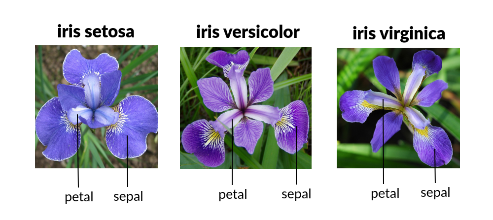

Porównanie gatunków

```r
# setwd("C:/R/demo")
knitr::include_graphics("C:/R/demo/iris.png")
```

Sprawdźimy czy średnie zmiennej `Sepal.Length` różnią się istotnie między gatunktami. Najpierw obliczymy średnie wartości.

```r
aggregate(Sepal.Length ~ Species,data=iris,mean) %>% kable()
```

| Species | Sepal.Length |
| --- | --- |
| setosa | 5.006 |
| versicolor | 5.936 |
| virginica | 6.588 |

Zapiszmy, który gatunek miał największą średnią.

```r
tabl=aggregate(Sepal.Length ~ Species,data=iris,mean)
gatunek=tabl$Species[which.max(tabl$Sepal.Length)] %>% as.character()
gatunek
```

```
## [1] "virginica"
```

Poniższy wykres ramka-wąsy ze względu na nieduży rozrzut wartości wokół średnich pozwala przypuszczać, że średnie różnią się istotnie

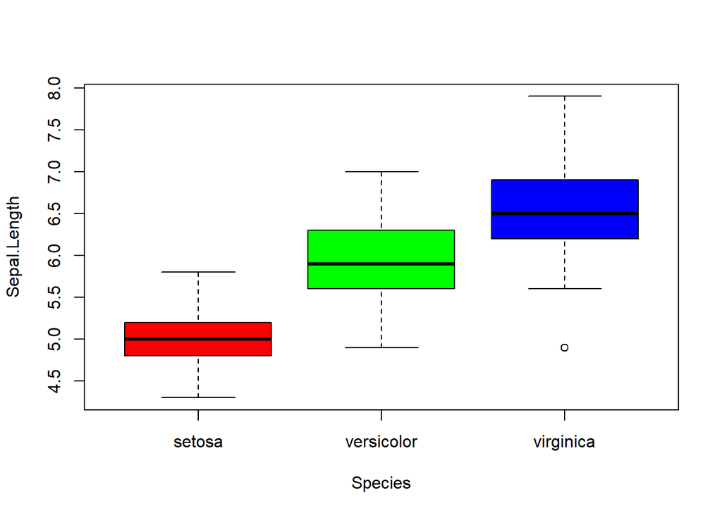

```r
boxplot(Sepal.Length ~ Species,data=iris,col=c('red','green','blue'))
```

Wykonamy test wielu średnich względem zmiennej `Species` wykorzystując funkcję `aov`.

```r
library(dplyr)
Anova=iris %>% aov(Sepal.Length ~ Species,data=.) %>% summary()
p.val=Anova[[1]][[5]]

Anova
```

```
##              Df Sum Sq Mean Sq F value Pr(>F)
## Species       2  63.21  31.606   119.3 <2e-16 ***
## Residuals   147  38.96   0.265
## ---
## Signif. codes:  0 '***' 0.001 '**' 0.01 '*' 0.05 '.' 0.1 ' ' 1
```

Rzeczywiście, średnie warości zmiennej `Sepal.Length` różnią się istotnie między gatunktami. P-wartość wyniosła w przybliżeniu 0, czyli mniej niż 0.05. Gatunek o najwyższej średniej to **virginica**.